# Flight Dataset Exploration

## Preliminary Wrangling

> Flight Dataset of the year 2008, contains various columns about delays and cancellation of the flights. Data Source: https://community.amstat.org/jointscsg-section/dataexpo/dataexpo2009

```python
# import all packages and set plots to be embedded inline
import numpy as np
import pandas as pd
import matplotlib.pyplot as plt
import seaborn as sb

%matplotlib inline
```

```python
#load data
flight = pd.read_csv('2008.csv')
flight.head()
```

|  | Year | Month | DayofMonth | DayOfWeek | DepTime | CRSDepTime | ArrTime | CRSArrTime | UniqueCarrier | FlightNum | ... | TaxiIn | TaxiOut | Cancelled | CancellationCode | Diverted | CarrierDelay | WeatherDelay | NASDelay | SecurityDelay | LateAircraftDelay |
| --- | --- | --- | --- | --- | --- | --- | --- | --- | --- | --- | --- | --- | --- | --- | --- | --- | --- | --- | --- | --- | --- |
| 0 | 2008 | 1 | 3 | 4 | 2003.0 | 1955 | 2211.0 | 2225 | WN | 335 | ... | 4.0 | 8.0 | 0 | NaN | 0 | NaN | NaN | NaN | NaN | NaN |
| 1 | 2008 | 1 | 3 | 4 | 754.0 | 735 | 1002.0 | 1000 | WN | 3231 | ... | 5.0 | 10.0 | 0 | NaN | 0 | NaN | NaN | NaN | NaN | NaN |
| 2 | 2008 | 1 | 3 | 4 | 628.0 | 620 | 804.0 | 750 | WN | 448 | ... | 3.0 | 17.0 | 0 | NaN | 0 | NaN | NaN | NaN | NaN | NaN |
| 3 | 2008 | 1 | 3 | 4 | 926.0 | 930 | 1054.0 | 1100 | WN | 1746 | ... | 3.0 | 7.0 | 0 | NaN | 0 | NaN | NaN | NaN | NaN | NaN |
| 4 | 2008 | 1 | 3 | 4 | 1829.0 | 1755 | 1959.0 | 1925 | WN | 3920 | ... | 3.0 | 10.0 | 0 | NaN | 0 | 2.0 | 0.0 | 0.0 | 0.0 | 32.0 |

5 rows × 29 columns

```python
flight.shape
```

```
(7009728, 29)
```

```python
flight.describe()
```

|  | Year | Month | DayofMonth | DayOfWeek | DepTime | CRSDepTime | ArrTime | CRSArrTime | FlightNum | ActualElapsedTime | ... | Distance | TaxiIn | TaxiOut | Cancelled | Diverted | CarrierDelay | WeatherDelay | NASDelay | SecurityDelay | LateAircraftDelay |
| --- | --- | --- | --- | --- | --- | --- | --- | --- | --- | --- | --- | --- | --- | --- | --- | --- | --- | --- | --- | --- | --- |
| count | 7009728.0 | 7.009728e+06 | 7.009728e+06 | 7.009728e+06 | 6.873482e+06 | 7.009728e+06 | 6.858079e+06 | 7.009728e+06 | 7.009728e+06 | 6.855029e+06 | ... | 7.009728e+06 | 6.858079e+06 | 6.872670e+06 | 7.009728e+06 | 7.009728e+06 | 1.524735e+06 | 1.524735e+06 | 1.524735e+06 | 1.524735e+06 | 1.524735e+06 |
| mean | 2008.0 | 6.375130e+00 | 1.572801e+01 | 3.924182e+00 | 1.333830e+03 | 1.326086e+03 | 1.481258e+03 | 1.494801e+03 | 2.224200e+03 | 1.273224e+02 | ... | 7.263870e+02 | 6.860852e+00 | 1.645305e+01 | 1.960618e-02 | 2.463006e-03 | 1.577206e+01 | 3.039031e+00 | 1.716462e+01 | 7.497434e-02 | 2.077098e+01 |
| std | 0.0 | 3.406737e+00 | 8.797068e+00 | 1.988259e+00 | 4.780689e+02 | 4.642509e+02 | 5.052251e+02 | 4.826728e+02 | 1.961716e+03 | 7.018731e+01 | ... | 5.621018e+02 | 4.933649e+00 | 1.133280e+01 | 1.386426e-01 | 4.956753e-02 | 4.009912e+01 | 1.950287e+01 | 3.189495e+01 | 1.837940e+00 | 3.925964e+01 |
| min | 2008.0 | 1.000000e+00 | 1.000000e+00 | 1.000000e+00 | 1.000000e+00 | 0.000000e+00 | 1.000000e+00 | 0.000000e+00 | 1.000000e+00 | 1.200000e+01 | ... | 1.100000e+01 | 0.000000e+00 | 0.000000e+00 | 0.000000e+00 | 0.000000e+00 | 0.000000e+00 | 0.000000e+00 | 0.000000e+00 | 0.000000e+00 | 0.000000e+00 |
| 25% | 2008.0 | 3.000000e+00 | 8.000000e+00 | 2.000000e+00 | 9.280000e+02 | 9.250000e+02 | 1.107000e+03 | 1.115000e+03 | 6.220000e+02 | 7.700000e+01 | ... | 3.250000e+02 | 4.000000e+00 | 1.000000e+01 | 0.000000e+00 | 0.000000e+00 | 0.000000e+00 | 0.000000e+00 | 0.000000e+00 | 0.000000e+00 | 0.000000e+00 |
| 50% | 2008.0 | 6.000000e+00 | 1.600000e+01 | 4.000000e+00 | 1.325000e+03 | 1.320000e+03 | 1.512000e+03 | 1.517000e+03 | 1.571000e+03 | 1.100000e+02 | ... | 5.810000e+02 | 6.000000e+00 | 1.400000e+01 | 0.000000e+00 | 0.000000e+00 | 0.000000e+00 | 0.000000e+00 | 6.000000e+00 | 0.000000e+00 | 0.000000e+00 |
| 75% | 2008.0 | 9.000000e+00 | 2.300000e+01 | 6.000000e+00 | 1.728000e+03 | 1.715000e+03 | 1.909000e+03 | 1.907000e+03 | 3.518000e+03 | 1.570000e+02 | ... | 9.540000e+02 | 8.000000e+00 | 1.900000e+01 | 0.000000e+00 | 0.000000e+00 | 1.600000e+01 | 0.000000e+00 | 2.100000e+01 | 0.000000e+00 | 2.600000e+01 |
| max | 2008.0 | 1.200000e+01 | 3.100000e+01 | 7.000000e+00 | 2.400000e+03 | 2.359000e+03 | 2.400000e+03 | 2.400000e+03 | 9.743000e+03 | 1.379000e+03 | ... | 4.962000e+03 | 3.080000e+02 | 4.290000e+02 | 1.000000e+00 | 1.000000e+00 | 2.436000e+03 | 1.352000e+03 | 1.357000e+03 | 3.920000e+02 | 1.316000e+03 |

8 rows × 24 columns

```python
flight.info()
```

```
<class 'pandas.core.frame.DataFrame'>
RangeIndex: 7009728 entries, 0 to 7009727
Data columns (total 29 columns):
 #   Column             Dtype
---  ------             -----
 0   Year               int64
 1   Month              int64
 2   DayofMonth         int64
 3   DayOfWeek          int64
 4   DepTime            float64
 5   CRSDepTime         int64
 6   ArrTime            float64
 7   CRSArrTime         int64
 8   UniqueCarrier      object
 9   FlightNum          int64
```

[output cut: 21 more lines]

```python
#checking for duplicates
flight.duplicated().sum()
```

```
4
```

```python
flight.drop_duplicates(inplace = True)
```

```python
flight.info()
```

```
<class 'pandas.core.frame.DataFrame'>
Int64Index: 7009724 entries, 0 to 7009727
Data columns (total 29 columns):
 #   Column             Dtype
---  ------             -----
 0   Year               int64
 1   Month              int64
 2   DayofMonth         int64
 3   DayOfWeek          int64
 4   DepTime            float64
 5   CRSDepTime         int64
 6   ArrTime            float64
 7   CRSArrTime         int64
 8   UniqueCarrier      object
 9   FlightNum          int64
```

[output cut: 21 more lines]

```python
#A- Carrier, B- Weather, C-National Air System(NASDelay), D- Security
flight['CancellationCode'].value_counts()
```

```
B    54904
A    54330
C    28188
D       12
Name: CancellationCode, dtype: int64
```

### What is the structure of your dataset?

> Dataset has 7009728 Rows and 29 Columns

### What is/are the main feature(s) of interest in your dataset?

> I will focus on: Arrival and Departual Times, Cancellation and Delay Reasons.

### What features in the dataset do you think will help support your investigation into your feature(s) of interest?

> Arrival and Departual Times and columns related to the cancellation and delay reasons.

## Univariate Exploration

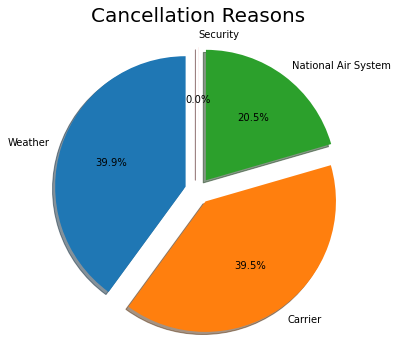

```python
#cancellation reasons
labels = 'Weather', 'Carrier','National Air System', 'Security'
plt.subplots(figsize=(14,6))
sorted_counts = flight['CancellationCode'].value_counts()
plt.title('Cancellation Reasons', fontsize=(20))
explode = (0.1, 0.1, 0.1,0.1)
plt.pie(sorted_counts ,labels= labels,autopct='%1.1f%%',startangle=90, shadow = True, explode=explode)
plt.show()
```

- The most reasons of cancellation are Weather and Carrier.

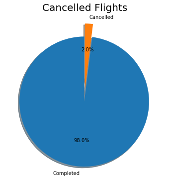

```python
#cancelled flights
labels = 'Completed', 'Cancelled'
plt.subplots(figsize=(14,6))
sorted_counts = flight['Cancelled'].value_counts()
plt.title('Cancelled Flights', fontsize=(20))
explode = (0.1, 0.1)
plt.pie(sorted_counts ,labels= labels,autopct='%1.1f%%',startangle=90, shadow = True, explode=explode)
plt.show()
```

- It appears that a lot of flights not cancelled

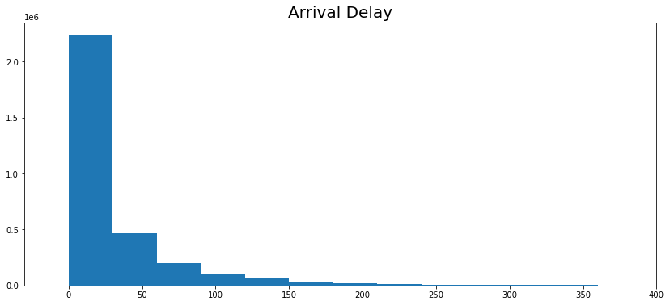

```python
#Arrival Delay
plt.subplots(figsize=(14,6))
plt.title('Arrival Delay', fontsize=(20))
bins = np.arange(0, flight['ArrDelay'].max()+0.5, 30)
plt.hist(data= flight, x= 'ArrDelay', bins=bins);
plt.xlim(-30,400);
```

- The Arrival distribution is right skewed, there are flights arrived before their time.

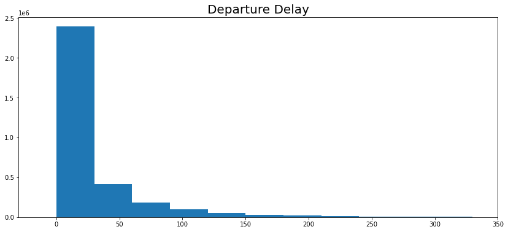

```python
#departure delay
plt.subplots(figsize=(14,6))
plt.title('Departure Delay', fontsize=(20))
bins = np.arange(0, flight['DepDelay'].max()+0.5, 30)
plt.hist(data= flight, x= 'DepDelay', bins=bins);
plt.xlim(-30,350);
```

- The departure time delay distribution is right skewed

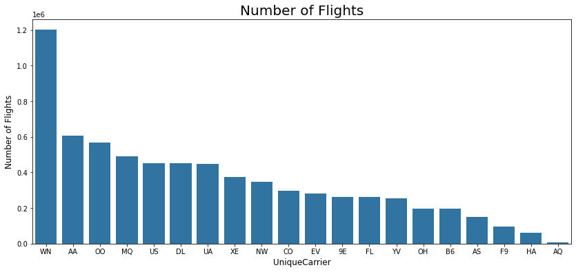

```python
#Number of flights
plt.subplots(figsize=(14,6))
plt.title('Number of Flights', fontsize=(20))
count_order = flight.UniqueCarrier.value_counts().index
base_color = sb.color_palette()[0]
sb.countplot(data = flight, x = 'UniqueCarrier', color = base_color, order = count_order);
plt.ylabel('Number of Flights', fontsize=(12))
plt.xlabel('UniqueCarrier', fontsize=(12))
```

- The WN Carrier has the most number of flights.

### Discuss the distribution(s) of your variable(s) of interest. Were there any unusual points? Did you need to perform any transformations?

> A lot of Flights arrived before their time and the most cancellation reason is weather.I didn't find any unusual points here. I didn't need any transformations.

### Of the features you investigated, were there any unusual distributions? Did you perform any operations on the data to tidy, adjust, or change the form of the data? If so, why did you do this?

> I didn't find any unusual distributions among the features investigated

## Bivariate Exploration

> In this section, investigate relationships between pairs of variables in your data. Make sure the variables that you cover here have been introduced in some fashion in the previous section (univariate exploration).

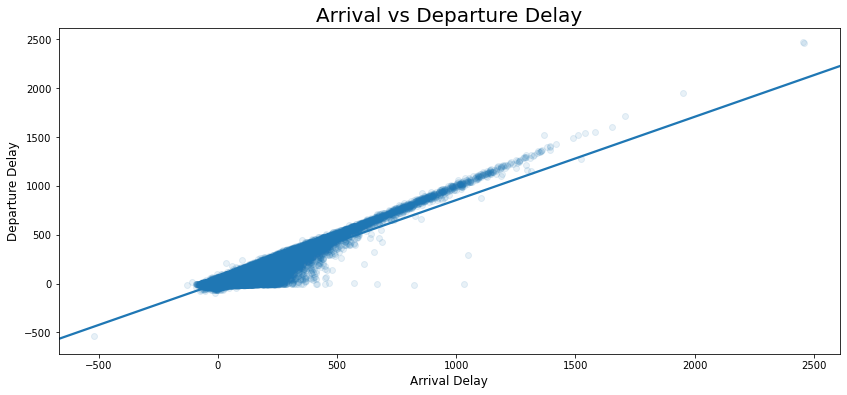

```python
#relation between Arrival and Departure
plt.figure(figsize=[14,6])
#plt.scatter(data = flight, x = 'ArrDelay', y = 'DepDelay', alpha=1/20);
sb.regplot(data = flight, x = 'ArrDelay', y = 'DepDelay', truncate=False, x_jitter=0.3, scatter_kws={'alpha':0.1});
plt.title('Arrival vs Departure Delay', fontsize =(20))
plt.xlabel('Arrival Delay', fontsize=(12))
plt.ylabel('Departure Delay', fontsize=(12))
```

- Positive correlation between Arrival and Departure Delay

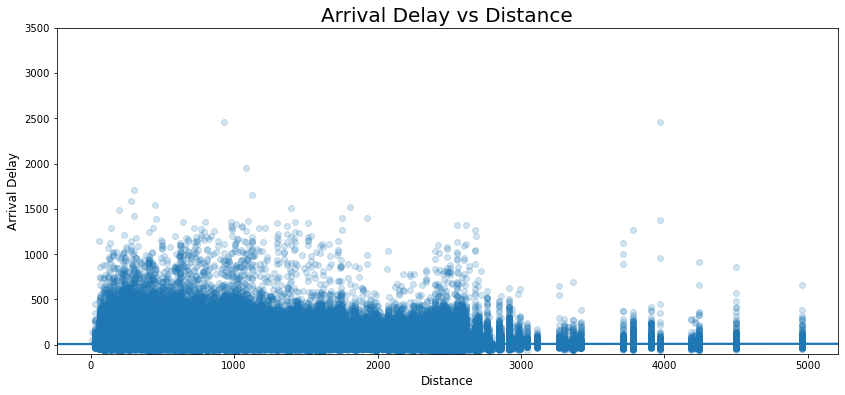

```python
#Arrival delay vs distance
plt.figure(figsize=[14,6])
#plt.scatter(data=flight, x="Distance", y="ArrDelay", s=1, alpha=1/5)
sb.regplot(data = flight, x = 'Distance', y = 'ArrDelay', truncate=False, x_jitter=0.3, scatter_kws={'alpha':1/5});
plt.title('Arrival Delay vs Distance', fontsize =(20))
plt.xlabel('Distance', fontsize=(12))
plt.ylabel('Arrival Delay', fontsize=(12))
plt.ylim([-100,3500]);
```

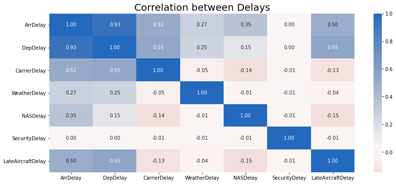

```python
#correlation between delays
variables = ['ArrDelay','DepDelay','CarrierDelay','WeatherDelay', 'NASDelay', 'SecurityDelay', 'LateAircraftDelay']
plt.figure(figsize=[14,6])
plt.title('Correlation between Delays', fontsize =(20))
sb.heatmap(flight[variables].corr(), annot=True, fmt=".2f",  cmap = 'vlag_r', center = 0)
```

- Security Delay has a weak relation vs other. There is a strong relation Arrival delay and departure delay.

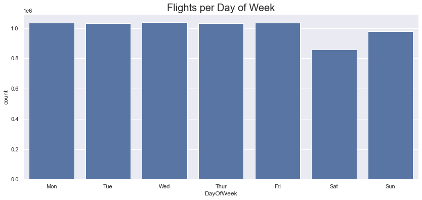

```python
#flights per Days
plt.figure(figsize=[14,6])
plt.title('Flights per Day of Week', fontsize =(20))
bins = np.arange(0, flight['DayOfWeek'].max()+0.5, 30)
base_color = sb.color_palette()[0]
days= ['Mon', 'Tue', 'Wed', 'Thur', 'Fri', 'Sat', 'Sun']
ax= sb.countplot(data= flight, x='DayOfWeek', color=base_color)
ax.set_xticklabels(days);
```

- Wednesday and Friday is the most days of flights. Minimum number of flights on Saturday

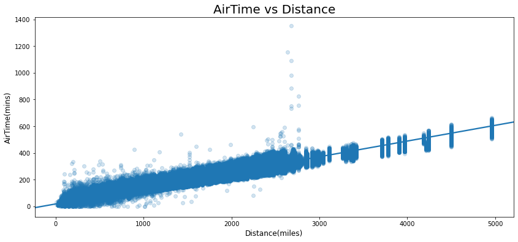

```python
#Air Time vs Distance
plt.figure(figsize=[14,6])
base_color = sb.color_palette()[0]
#flight.plot(x = 'Distance', y = 'AirTime', kind = 'scatter', color=base_color,s=10)
#plt.scatter(data = flight, x = 'Distance', y = 'AirTime', alpha=0.1);
sb.regplot(data = flight, x = 'Distance', y = 'AirTime', truncate=False, x_jitter=0.3, scatter_kws={'alpha':1/5});
plt.title('AirTime vs Distance', fontsize =(20))
plt.xlabel('Distance(miles)', fontsize=(12))
plt.ylabel('AirTime(mins)', fontsize=(12));
```

- Positive correlation between Air Time and Distance. When Distance increase the Air Time increase.

### Talk about some of the relationships you observed in this part of the investigation. How did the feature(s) of interest vary with other features in the dataset?

> Positive correlation between Arrival and Departure Delay. Security Delay has a weak relation vs other. There is a strong relation Arrival delay and departure delay. Positive correlation between Air Time and Distance. When Distance increase the Air Time increase.

### Did you observe any interesting relationships between the other features (not the main feature(s) of interest)?

> No.

## Multivariate Exploration

> Create plots of three or more variables to investigate your data even further. Make sure that your investigations are justified, and follow from your work in the previous sections.

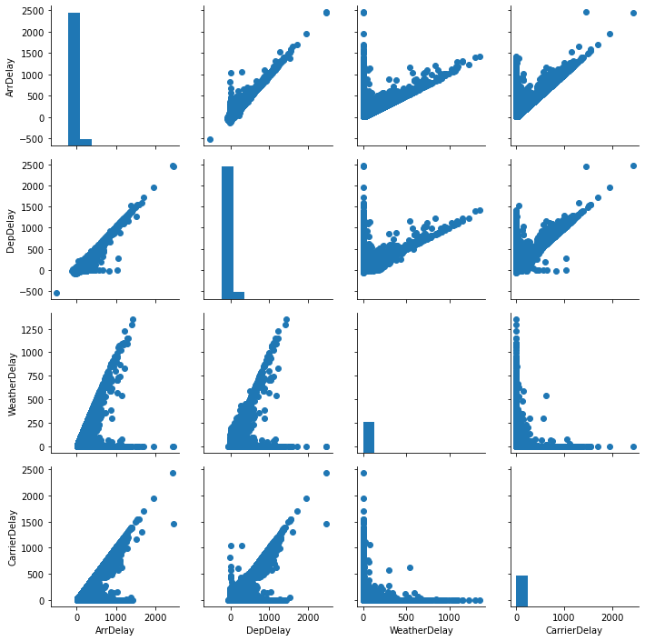

```python
g = sb.PairGrid(data=flight, vars = ['ArrDelay', 'DepDelay','WeatherDelay', 'CarrierDelay'])
g.map_diag(plt.hist)
g.map_offdiag(plt.scatter)
```

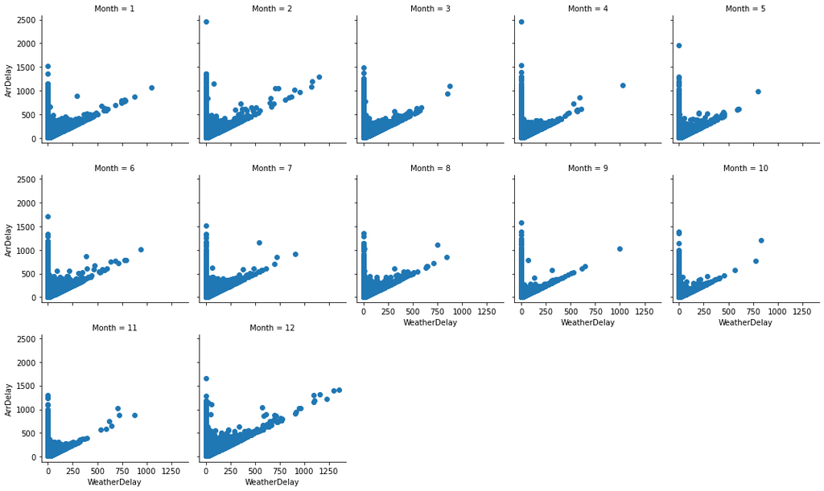

```python
g=sb.FacetGrid(data=flight, col='Month', col_wrap=5)
g.map(plt.scatter,'WeatherDelay','ArrDelay')
```

- Positive correlation between weather delay and arrival delay. Jan, Feb and Dec have the most delyas.

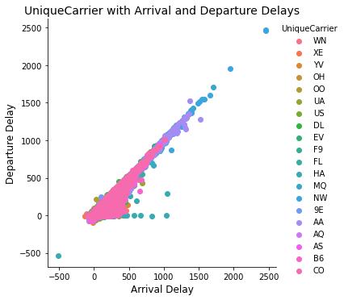

```python
g = sb.FacetGrid(data = flight, hue = 'UniqueCarrier', height = 5)
g.map(plt.scatter, 'ArrDelay', 'DepDelay')
g.add_legend()
plt.title('UniqueCarrier with Arrival and Departure Delays', fontsize =(14))
plt.xlabel('Arrival Delay',  fontsize=(12))
plt.ylabel('Departure Delay',  fontsize=(12))
```

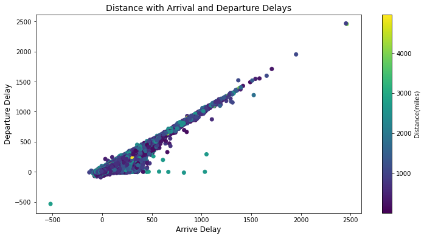

```python
#distance with arrival and departure delays
plt.figure(figsize=[12,6])
plt.scatter(data= flight, x='ArrDelay', y='DepDelay', c='Distance');
plt.colorbar(label='Distance(miles)')
plt.ylabel('Departure Delay', fontsize=(12))
plt.xlabel('Arrive Delay', fontsize=(12));
plt.title('Distance with Arrival and Departure Delays', fontsize =(14))
```